# Stat542: Variable Selection – A Toy Example

```r
mypackages = c("leaps", "glmnet")
tmp = setdiff(mypackages, rownames(installed.packages()))
if (length(tmp) > 0) install.packages(tmp)

library(leaps)  # regsubsets
library(glmnet)  # glmnet for lasso
```

This example is from simulation example 1 of [Zhao and Yu](http://www.jmlr.org/papers/volume7/zhao06a/zhao06a.pdf) (2006), which shows that LASSO could fail to pick the correct variable set when the so-called Irrepresentable Condition is violated.

Consider a simple linear regression model with three predictors $X_1, X_2,$ and $X_3$, and the response variable $Y$ is modeled as
$$Y = 2 \cdot X_1 + 3 \cdot X_2 + N(0, 1),$$
that is, the last predictor $X_3$ is irrelevant. The three predictors are generated as follows: $X_1 \sim N(0,1)$, $X_2 \sim N(0, 1)$, and
$$X_3 = \frac{2}{3} X_1 + \frac{2}{3} X_2 + N \left ( 0, \frac{1}{3^2} \right ).$$
Generate $n=1000$ samples from this model.

```r
# set random seed in case you want to reproduce the result
set.seed(542)
n = 1000
x1 = rnorm(n)
x1 = rnorm(n)
x2 = rnorm(n)
e = rnorm(n)
x3 = 2/3 * x1 + 2/3 * x2 + 1/3 * e
epsilon = rnorm(n)
beta = c(2, 3)
y = beta[1] * x1 + beta[2] * x2 + epsilon
myData = data.frame(y = y, x1 = x1, x2 = x2, x3 = x3)
```

#### Use AIC/BIC to select the best sub-model

```r
IC = regsubsets(y ~ ., myData, method = "exhaustive")
sumIC = summary(IC)
sumIC$bic
```

```
## [1] -1488.766 -2581.920 -2575.242
```

```r
sumIC
```

```
## Subset selection object
## Call: regsubsets.formula(y ~ ., myData, method = "exhaustive")
## 3 Variables  (and intercept)
##    Forced in Forced out
## x1     FALSE      FALSE
## x2     FALSE      FALSE
## x3     FALSE      FALSE
## 1 subsets of each size up to 3
## Selection Algorithm: exhaustive
##          x1  x2  x3
## 1  ( 1 ) " " " " "*"
## 2  ( 1 ) "*" "*" " "
## 3  ( 1 ) "*" "*" "*"
```

```r
msize = apply(sumIC$which, 1, sum)
AIC = n * log(sumIC$rss/n) + 2 * msize
BIC = n * log(sumIC$rss/n) + log(n) * msize
AIC; BIC
```

```
##          1          2          3
## 1113.79020   15.72812   17.49869
```

```
##          1          2          3
## 1123.60571   30.45139   37.12971
```

The lowest AIC/BIC is given by $Y \sim X_1 + X_2$, that is, these two procedures choose the correct sub-model.

#### Use LASSO

Next, we use LASSO with lambda.min and lambda.1se to check if it can select the correct model.

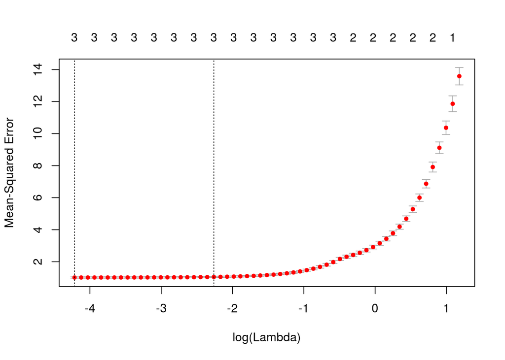

```r
mylasso.cv = cv.glmnet(as.matrix(myData[, c('x1', 'x2', 'x3')]), as.vector(myData$y))
plot(mylasso.cv)
```

```r
coef(mylasso.cv, s = 'lambda.1se')
```

```
## 4 x 1 sparse Matrix of class "dgCMatrix"
##                       1
## (Intercept) -0.05015789
## x1           1.60443649
## x2           2.69940979
## x3           0.36282687
```

```r
coef(mylasso.cv, s = 'lambda.min')
```

```
## 4 x 1 sparse Matrix of class "dgCMatrix"
##                       1
## (Intercept) -0.04624025
## x1           1.87702903
## x2           2.97065701
## x3           0.09587310
```

Neither approach selects the correct model. The following code provides two path plots of LASSO: the x-coordinate is the L1-norm of the coefficients in the “norm” plot and the x-coorindate is log-lambda in the “lambda” plot. You can see that $X_3$ won’t be dropped out of the model unless log-lambda is going to $-\infty$ (or equivalently $\lambda \to 0$). Thus it is impossible for LASSO to select the correct model.

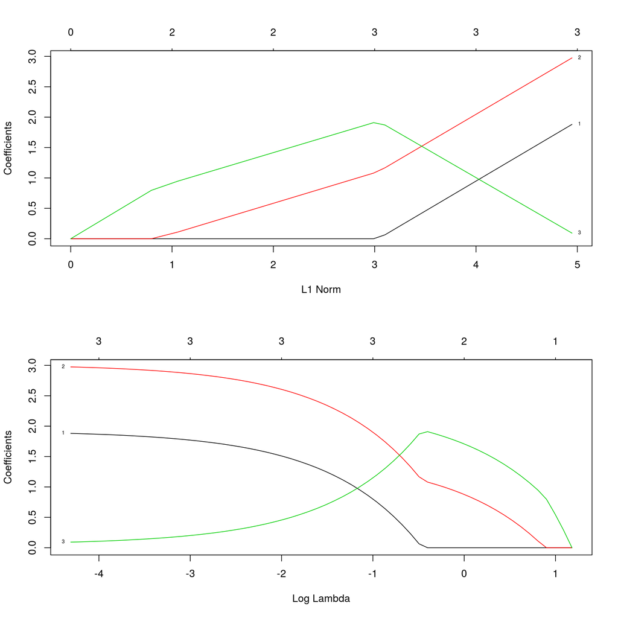

```r
mylasso = glmnet(as.matrix(myData[, c('x1', 'x2', 'x3')]), as.vector(myData$y))
par(mfrow = c(2, 1))
plot(mylasso, label=TRUE, xvar = "norm")
plot(mylasso, label=TRUE, xvar = "lambda")
```

#### Compare prediction performance

Next we can compare the corresponding prediction error on a test set.

```r
N = 1000
mytestData = matrix(0, N, 4)
colnames(mytestData) = c("x1", "x2", "x3", "y")
mytestData = as.data.frame(mytestData)

mytestData$x1 = rnorm(N)
mytestData$x2 = rnorm(N)
mytestData$x3 = 2/3 * x1 + 2/3 * x2 + 1/3 * rnorm(N)
mytestData$y = beta[1] * mytestData$x1 +
  beta[2] * mytestData$x2 + rnorm(N)
```

For Lasso, you can form prediction using one of the following approaches:

- Use the coefficients from lambda.1se;
- Use the coefficients from lambda.min;
- Refit a LS model using variables selected by lambda.1se;
- Refit a LS model using variables selected by lambda.min.

In this example, lambda.1se and lambda.min select the same model, the full model.

There are two commands for Lasso prediction: one takes the output from `cv.glmnet` as input (where you can use lambda.min and lambda.1se), and the other one takes the output from `glmnet` as input.

The results below indicate that for this example, the test error from the Refit procedure is not bad even though the model is wrong.

```r
?predict.cv.glmnet
?predict.glmnet

tmp = predict(mylasso.cv, s="lambda.min",
              newx=data.matrix(mytestData)[, -4])
mean((mytestData$y - tmp)^2)
```

```
## [1] 1.065004
```

```r
tmp = predict(mylasso.cv, s="lambda.1se",
              newx=data.matrix(mytestData)[, -4])
mean((mytestData$y - tmp)^2)
```

```
## [1] 1.367122
```

```r
myfit.full = lm(y ~ ., myData)
tmp = predict(myfit.full, newdata=mytestData)
mean((mytestData$y - tmp)^2)
```

```
## [1] 1.057659
```

```r
myfit.AIC = lm(y ~ x1 + x2, myData)
tmp = predict(myfit.AIC, newdata=mytestData)
mean((mytestData$y - tmp)^2)
```

```
## [1] 1.060607
```